# Day 14 - Data Visualization in R

MAHESH DIVAKARAN

2/5/2021

# Data Visualization in R

- With the help of visualization techniques, humans can easily gain insights about the hidden patterns in data which might otherwise be neglected.
- Using data visualization, one can work with large datasets to efficiently obtain key insights about it.

### R Visualization Packages

- r-base
- ggplot2
- plotly
- shiny
- googleViz
- geofacet
- leaflet
- ggiraph
- tidyquant
- ….
- **Standard Graphics**
- Scatterplots
- Boxplots
- Piecharts
- Barplots etc.
- **Statistical Graphic**
- Data
- Aesthetic Mappings
- Geometric Objects
- Statistical Transformations
- Scales
- Coordinates system
- Faceting
- Wordmaps
- Correlations
- etc…

### R - Pie Charts

`pie(x, labels, radius, main, col, clockwise)`

- `x` is a vector containing the numeric values used in the pie chart.
- `labels` is used to give description to the slices.
- `radius` indicates the radius of the circle of the pie chart.(value between −1 and +1).
- `main` indicates the title of the chart.
- `col` indicates the color palette.
- `clockwise` is a logical value indicating if the slices are drawn clockwise or anti clockwise.

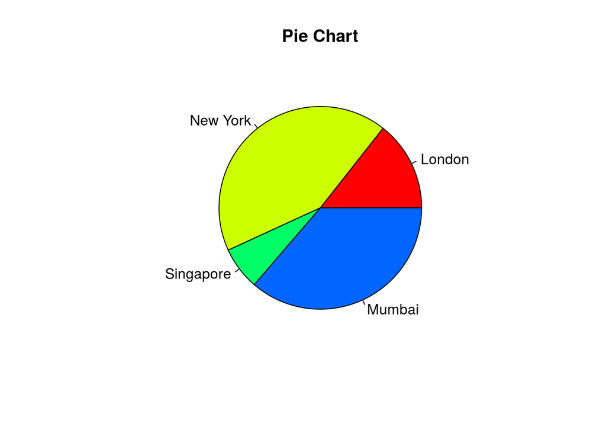

```r
# Create data for the graph.
x <- c(21, 62, 10, 53)
labels <- c("London", "New York", "Singapore", "Mumbai")

# Plot the chart.
pie(x,labels, main = "Pie Chart", col = rainbow(5))
```

```r
# Create data for the graph.
x <- c(21, 62, 10, 53)
labels <- c("London", "New York", "Singapore", "Mumbai")

# Give the chart file a name.
png(file = "city.png")

# Plot the chart.
pie(x,labels, main = "Pie Chart", col = rainbow(5))

# Save the file.
dev.off()
```

### Slice Percentages and Chart Legend

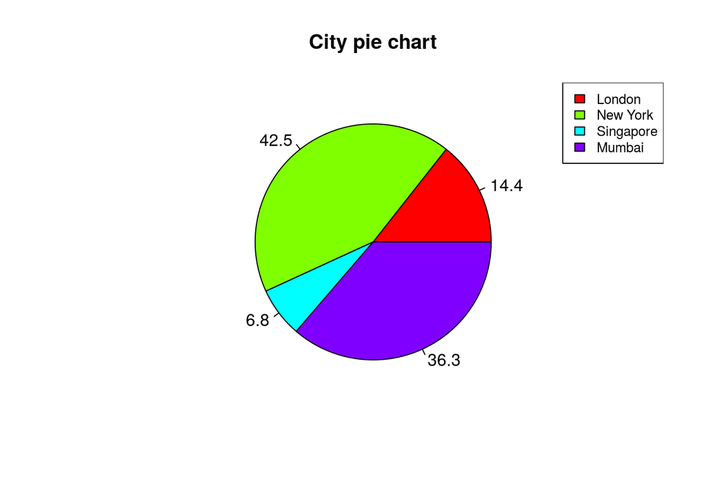

```r
piepercent<- round(100*x/sum(x), 1)

# Plot the chart.
pie(x, labels = piepercent, main = "City pie chart",col = rainbow(length(x)))
legend("topright", c("London","New York","Singapore","Mumbai"), cex = 0.8,
   fill = rainbow(length(x)))
```

### 3D Pie Chart

```r
# Get the library.
library(plotrix)


# Give the chart file a name.
png(file = "3d_pie_chart.jpg")

# Plot the chart.
pie3D(x,labels = labels,explode = 0.1, main = "Pie Chart of Countries ")

# Save the file.
dev.off()
```

## R - Bar Charts

`barplot(H,xlab,ylab,main, names.arg,col)`

- `H` is a vector or matrix containing numeric values used in bar chart.
- `xlab` is the label for x axis.
- `ylab` is the label for y axis.
- `main` is the title of the bar chart.
- `names.arg` is a vector of names appearing under each bar.
- `col` is used to give colors to the bars in the graph.

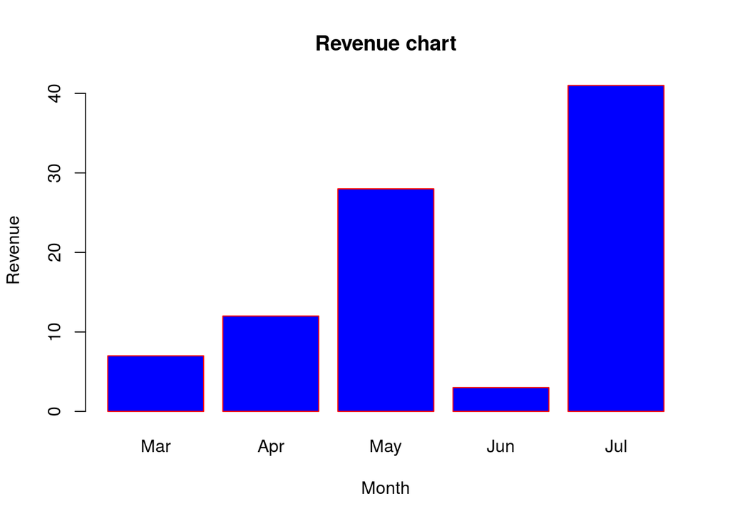

```r
# Create the data for the chart
H <- c(7,12,28,3,41)
label <- c("Mar","Apr","May","Jun","Jul")

# Plot the bar chart
barplot(H, names.arg=label ,xlab="Month", ylab="Revenue", col="blue", main="Revenue chart",border="red")
```

```r
# Give the chart file a name
png(file = "barchart_months_revenue.png")

# Plot the bar chart
barplot(H,names.arg=label,xlab="Month",ylab="Revenue",col="blue",main="Revenue chart",border="red")

# Save the file
dev.off()
```

### Group Bar Chart and Stacked Bar Chart

```r
# Create the input vectors.
colors <- c("green","orange","brown")
months <- c("Mar","Apr","May","Jun","Jul")
regions <- c("East","West","North")

# Create the matrix of the values.
Values <- matrix(c(2,9,3,11,9,4,8,7,3,12,5,2,8,10,11), nrow = 3, ncol = 5, byrow = TRUE)
Values
```

```
##      [,1] [,2] [,3] [,4] [,5]
## [1,]    2    9    3   11    9
## [2,]    4    8    7    3   12
## [3,]    5    2    8   10   11
```

```r
# Give the chart file a name
png(file = "barchart_stacked.png")

# Create the bar chart
barplot(Values, main = "Total revenue", names.arg = months, xlab = "month", ylab = "revenue", col = colors)

# Add the legend to the chart
legend("topleft", regions, cex = 1.3, fill = colors)

# Save the file
dev.off()
```

## R - Histograms

`hist(v,main,xlab,xlim,ylim,breaks,col,border)`

- `v` is a vector containing numeric values used in histogram.
- `main` indicates title of the chart.
- `col` is used to set color of the bars.
- `border` is used to set border color of each bar.
- `xlab` is used to give description of x-axis.
- `xlim` is used to specify the range of values on the x-axis.
- `ylim` is used to specify the range of values on the y-axis.
- `breaks` is used to mention the width of each bar.

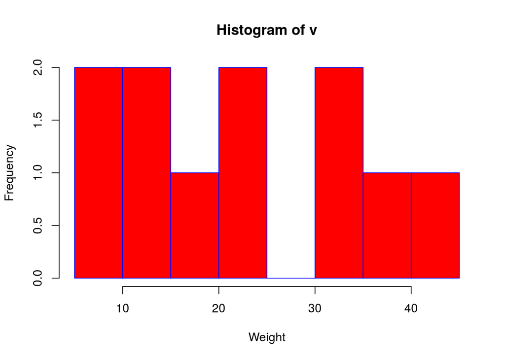

```r
# Create data for the graph.
v <-  c(9,13,21,8,36,22,12,41,31,33,19)


# Create the histogram.
hist(v,xlab = "Weight",col = "red",border = "blue", breaks = 9)
```

### Range of X and Y values

```r
# Create data for the graph.
v <- c(9,13,21,8,36,22,12,41,31,33,19)

# Give the chart file a name.
png(file = "histogram_lim_breaks.png")

# Create the histogram.
hist(v,xlab = "Weight",col = "green",border = "red", xlim = c(0,40), ylim = c(0,5),
   breaks = 5)

# Save the file.
dev.off()
```

## R - Line Graphs

`plot(v,type,col,xlab,ylab)`

- `v` is a vector containing the numeric values.
- `type` takes the value “`p`” to draw only the points, “`l`” to draw only the lines and “`o`” to draw both points and lines.
- `xlab` is the label for x axis.
- `ylab` is the label for y axis.
- `main` is the Title of the chart.
- `col` is used to give colors to both the points and lines.

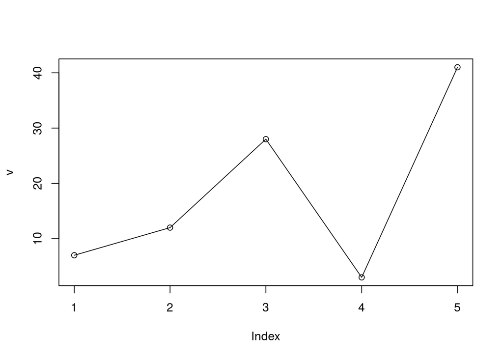

```r
# Create the data for the chart.
v <- c(7,12,28,3,41)


# Plot the bar chart.
plot(v,type = "o")
```

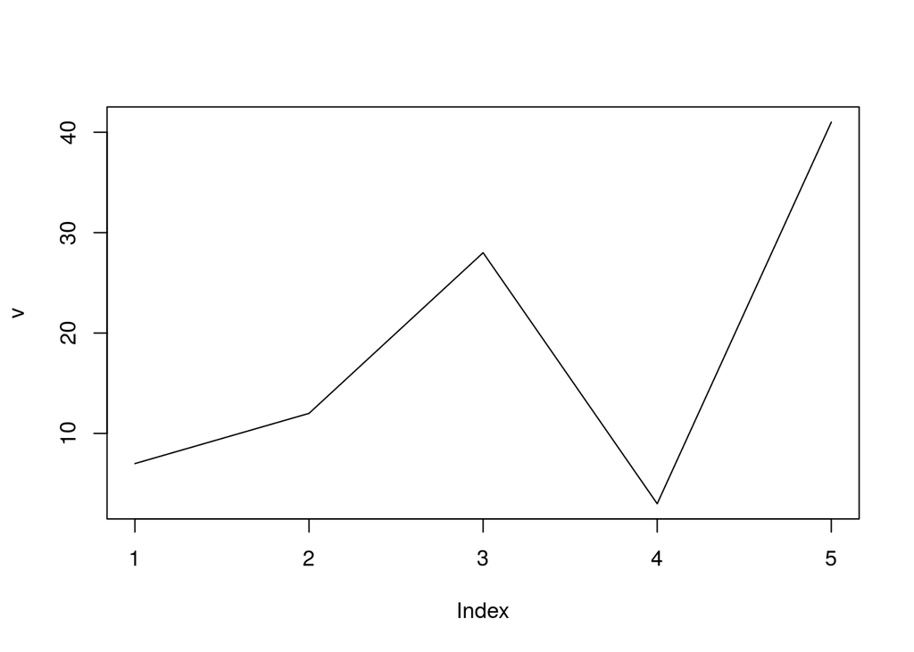

```r
plot(v,type = "l")
```

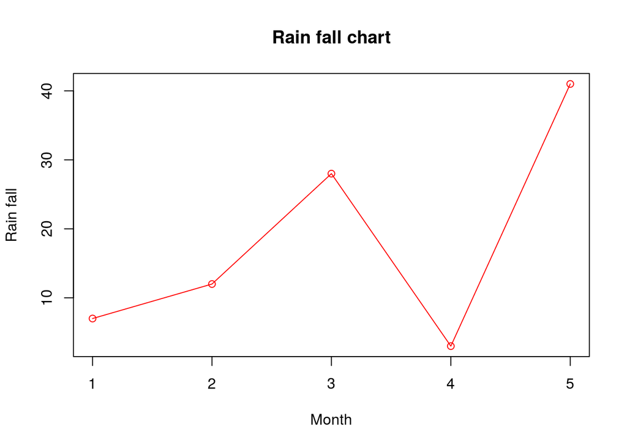

```r
# Plot the bar chart.
plot(v,type = "o", col = "red", xlab = "Month", ylab = "Rain fall",
   main = "Rain fall chart")
```

### Multiple Line plots

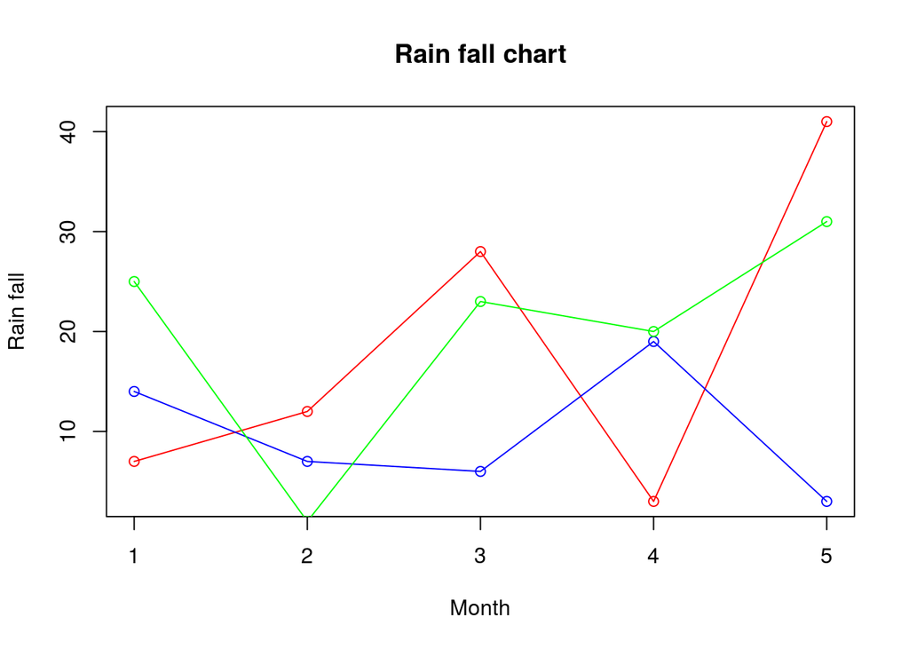

```r
# Create the data for the chart.
v <- c(7,12,28,3,41)
t <- c(14,7,6,19,3)
z <- c(25,1,23,20,31)

# Give the chart file a name.
#png(file = "line_chart_2_lines.jpg")

# Plot the bar chart.
plot(v,type = "o",col = "red", xlab = "Month", ylab = "Rain fall",
   main = "Rain fall chart")

lines(t, type = "o", col = "blue")
lines(z, type = "o", col = "green")
```

```r
# Save the file.
#dev.off()
```

## R - Scatterplots

`plot(x, y, main, xlab, ylab, xlim, ylim, axes)`

```r
input <- mtcars[,c('wt','mpg')]
print(head(input))
```

```
##                      wt  mpg
## Mazda RX4         2.620 21.0
## Mazda RX4 Wag     2.875 21.0
## Datsun 710        2.320 22.8
## Hornet 4 Drive    3.215 21.4
## Hornet Sportabout 3.440 18.7
## Valiant           3.460 18.1
```

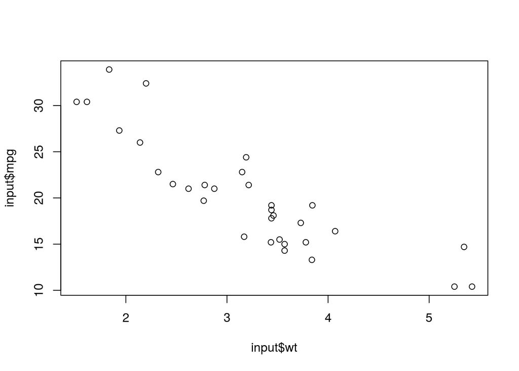

```r
# Plot the chart
plot(x = input$wt,y = input$mpg)
```

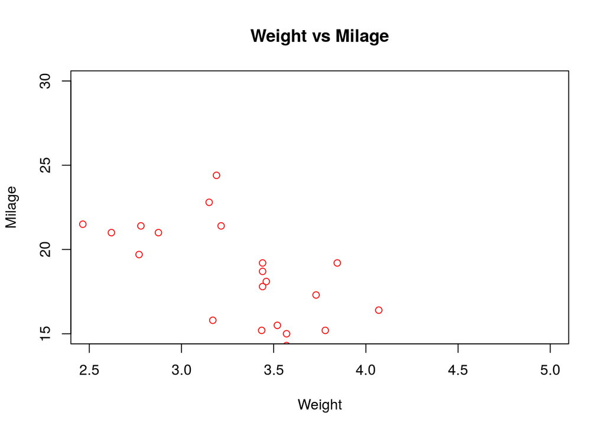

```r
# Plot the chart
plot(x = input$wt,y = input$mpg,
   xlab = "Weight",
   ylab = "Milage",
   xlim = c(2.5,5),
   ylim = c(15,30),
   main = "Weight vs Milage",
   col = "red"
)
```

## Data Visualization in R using ggplot2

```r
library(ggplot2)

head(mtcars)
```

```
##                    mpg cyl disp  hp drat    wt  qsec vs am gear carb
## Mazda RX4         21.0   6  160 110 3.90 2.620 16.46  0  1    4    4
## Mazda RX4 Wag     21.0   6  160 110 3.90 2.875 17.02  0  1    4    4
## Datsun 710        22.8   4  108  93 3.85 2.320 18.61  1  1    4    1
## Hornet 4 Drive    21.4   6  258 110 3.08 3.215 19.44  1  0    3    1
## Hornet Sportabout 18.7   8  360 175 3.15 3.440 17.02  0  0    3    2
## Valiant           18.1   6  225 105 2.76 3.460 20.22  1  0    3    1
```

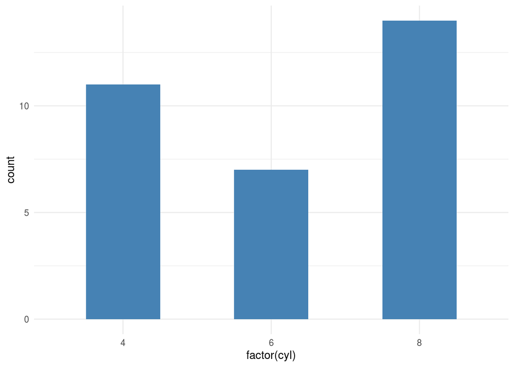

```r
# Basic barplot
p <- ggplot(mtcars, aes(x=factor(cyl)))+
  geom_bar(stat="count", width=0.5, fill="steelblue") +
  theme_minimal()

p
```

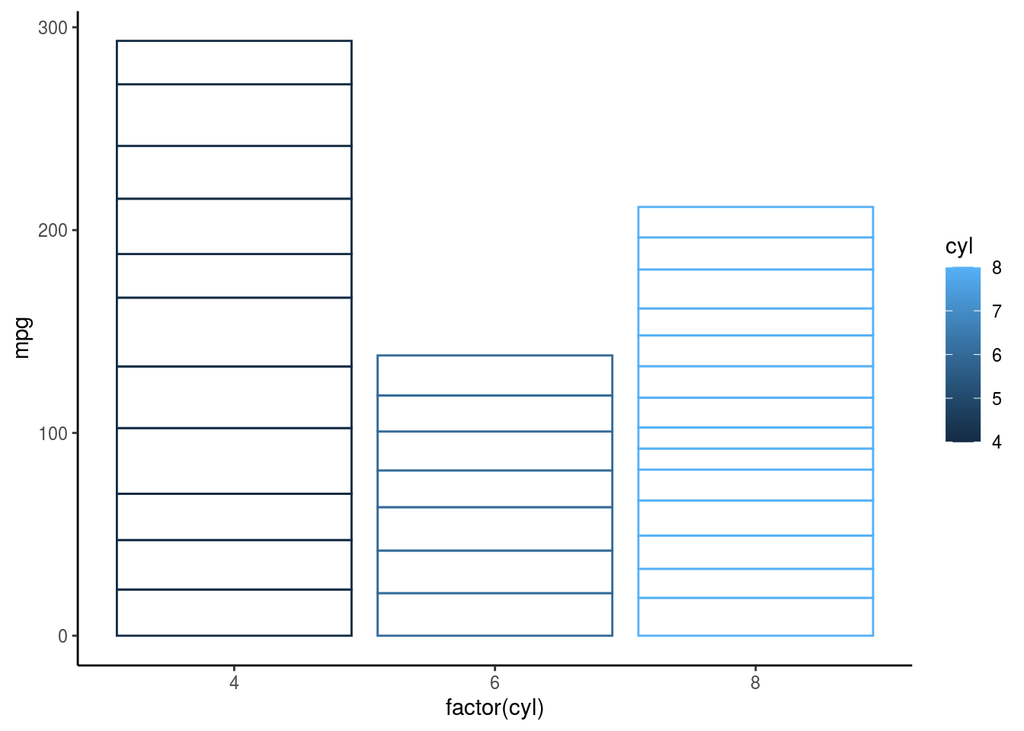

```r
# Change barplot line colors by groups
p <- ggplot(mtcars, aes(x=factor(cyl), y=mpg, color=cyl)) +
  geom_bar(stat="identity", fill="white") +
  theme_classic()
p
```

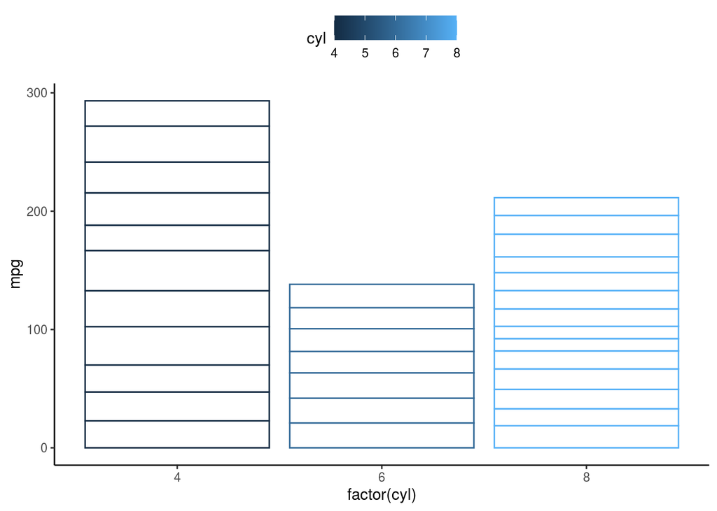

```r
# Change bar fill colors to blues
p <- p+scale_fill_brewer(palette="Blues")
p + theme(legend.position="top")
```

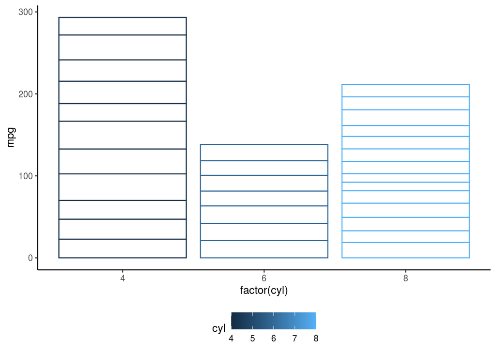

```r
p + theme(legend.position="bottom")
```

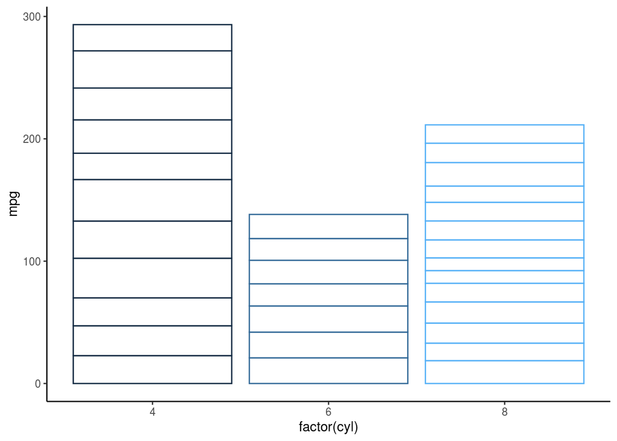

```r
# Remove legend
p + theme(legend.position="none")
```

### Barplot with multiple groups

```r
df2 <- data.frame(supp=rep(c("VC", "OJ"), each=3),
                dose=rep(c("D0.5", "D1", "D2"),2),
                len=c(6.8, 15, 33, 4.2, 10, 29.5))
head(df2)
```

```
##   supp dose  len
## 1   VC D0.5  6.8
## 2   VC   D1 15.0
## 3   VC   D2 33.0
## 4   OJ D0.5  4.2
## 5   OJ   D1 10.0
## 6   OJ   D2 29.5
```

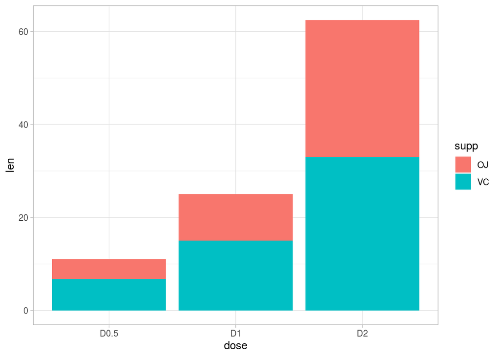

```r
# Stacked barplot with multiple groups
ggplot(data=df2, aes(x=dose, y=len, fill=supp)) +
  geom_bar(stat="identity") +
  theme_light()
```

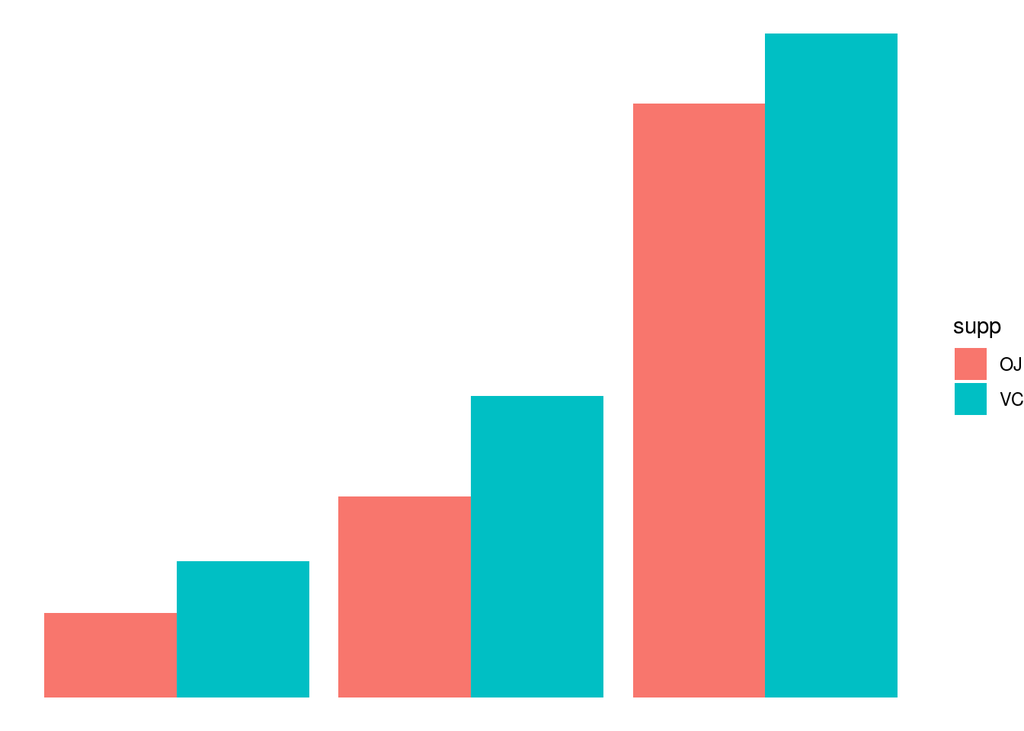

```r
# Use position=position_dodge()
ggplot(data=df2, aes(x=dose, y=len, fill=supp)) +
geom_bar(stat="identity", position=position_dodge())+
  theme_void()
```

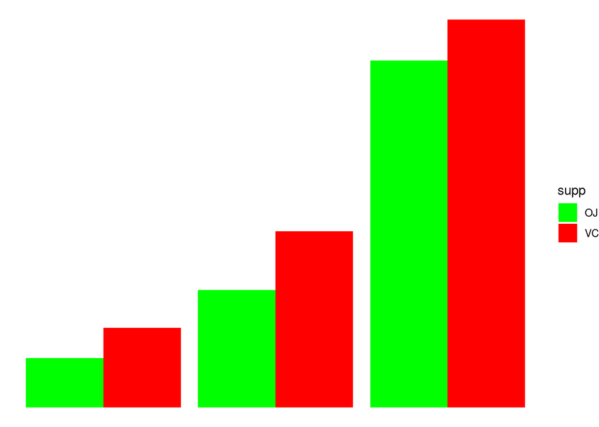

```r
# Use position=position_dodge()
ggplot(data=df2, aes(x=dose, y=len, fill=supp)) +
geom_bar(stat="identity", position=position_dodge())+
   scale_fill_manual(values = c("green","red"))+
  theme_void()
```